# R Notebook

load libraries

```r
library(tidyverse)
library(janitor)
```

load data

```r
revenue_breakdown <- clean_names(CodeClanData::qb_revenue_breakdown)
monthly_sales <- clean_names(CodeClanData::qb_monthly_sales)
competitors <- clean_names(CodeClanData::qb_competitors)
device_data <- clean_names(CodeClanData::qb_device_data)
```

create theme **Couldn’t work out how to make lines faint but used a fainter colour instead**

```r
my_theme <- theme(panel.background = element_rect(fill = "white"),
                  axis.line = element_line(size = 1),
                  panel.grid.major = element_line(colour = "azure2", size = 0.2),
                  text = element_text(size = 12),
                  title = element_text(size = 16, hjust = 0.5),
                  axis.title = element_text(size = 8))

col_scheme <- c("#E89FE9", "#50434F", "#B6A7B5", "#F9A472", "#BD7040")
```

# Question 1.

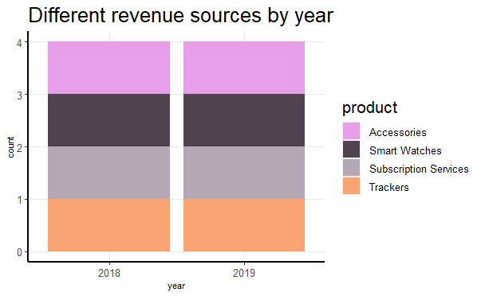

Question 2. Make a line chart showing monthly sales of the “flagship product” - the ‘KwikBit Unit 1’ - over the last year. This data is inside qb_monthly_sales, but you will need to use filter() or subset() (base R).

```r
monthly_sales %>%
  filter(cashflow == "Kwikbit Unit 1 Sales") %>%
  ggplot(aes(x = date, y = amount))+
  geom_line(colour = col_scheme[1])+
  labs(title = "Monthly sales of Kwikbit Unit 1")+
  my_theme

#got the colour after answers pushed
```

[output not shown]

Question 3. Make a line chart showing monthly revenue and costs over the last year. This data is also in qb_monthly_sales.

```r
monthly_sales %>%
  ggplot()+
  geom_line(aes(x = date, y = amount, colour = cashflow))+
  labs(title = "Monthly sales and revenue breakdown")+
  scale_fill_manual(values = col_scheme)+
  my_theme
```

[output not shown]

Question 4. Show annual sales of personal fitness trackers over the last 5 years broken down by company as a ribbon plot (use geom_area). This data is in qb_competitors.

```r
competitors %>%
  ggplot(aes(x = year, y = revenue, fill = company))+
  geom_area()+
  labs(title = "Annual sales of fitness trackers by competitors")+
  scale_y_continuous(labels = scales::comma)+
  scale_fill_manual(values = col_scheme)+
  my_theme


competitors %>%
  ggplot(aes(x = year, y = revenue, fill = company))+
  geom_area()+
  labs(title = "Annual sales of fitness trackers by competitors")+
  scale_y_continuous(labels = scales::comma)+
  facet_wrap(~company, ncol = 2)+
  scale_fill_manual(values = col_scheme)+
  my_theme
```

[output not shown]

Question 5. Now show the sales from the four competitors as a line graph. Include an extra layer that shows the data points used to make the lines.

```r
competitors %>%
  ggplot(aes(x = year, y = revenue, colour = company))+
  geom_line()+
  geom_point()+
  labs(title = "Annual revenue of competitors")+
  scale_fill_manual(values = col_scheme)+
  my_theme
```

[output not shown]

Question 6. Now the company wants to compare the number of steps that their device counts vs. their competitors. Make a line graph of the number of steps throughout time, and use faceting to compare between companies and people. The data for this is in qb_device_data.

[figure not shown]

2.2 Part 2 Question 1. Take the plots that you produced in part one and now polish them by:

Adding appropriate labels Changing the scales and coordinates when appropriate. Applying a unified theme, which is described below: Graphs should have white backgrounds, and use colour sparingly. There should be faint grid lines. Font sizes should be ~12pt although titles should be slightly larger and axis labels can be slightly smaller. All plots should use colours from the following company colour scheme.

col_scheme <- c(“#E89FE9”, “#50434F”, “#B6A7B5”, “#F9A472”, “#BD7040”)

3 Extension Question 1. Try out different ways of plotting these three datasets. Which graphs do you think are particularly effective at showing QikBit’s success?